# Practical ML - W4: Coursera Project

Tanish Sharma

14/08/2021

## Introduction

Using devices such as Jawbone Up, Nike FuelBand, and Fitbit it is now possible to collect a large amount of data about personal activity relatively inexpensively. These type of devices are part of the quantified self movement – a group of enthusiasts who take measurements about themselves regularly to improve their health, to find patterns in their behavior, or because they are tech geeks. One thing that people regularly do is quantify how much of a particular activity they do, but they rarely quantify how well they do it.

The dataset used for this project is [Weight Lifting Exercises Dataset](http://web.archive.org/web/20161224072740/http:/groupware.les.inf.puc-rio.br/har)[^1]. The goal of this project is to use data from accelerometers on the belt, forearm, arm, and dumbell of 6 participants and predict the manner in which they did the exercise. The prediction variable is “classe” in the training dataset.

Class A corresponds to the specified execution of the exercise, while the other 4 classes correspond to common mistakes. Participants were supervised by an experienced weight lifter to make sure the execution complied to the manner they were supposed to simulate. The exercises were performed by six male participants aged between 20-28 years, with little weight lifting experience. We made sure that all participants could easily simulate the mistakes in a safe and controlled manner by using a relatively light dumbbell (1.25kg).

## Loading libraries and dataset

```r
library(caret)
library(corrplot)
library(gbm)
library(randomForest)
library(rpart)
library(kernlab)
set.seed(1221)

training <- read.csv("../Downloads/pml-training.csv", na.strings = c("","#DIV/0!", NA));
testing <- read.csv("../Downloads/pml-testing.csv", na.strings = c("", "#DIV/0!", NA));

# Checking the dimensions of training dataset
dim(training)
```

```
[1] 19622   160
```

```r
#Checking the dimensions of testing dataset
dim(testing)
```

```
[1]  20 160
```

## Exploration and cleaning of dataset

First, we’ll remove all the columns from the dataset that doesn’t contain any relevant(for our analysis) data:

```r
training <- training[, colSums(is.na(training))==0];
testing <- testing[,colSums(is.na(testing))==0];

names(training);
```

```
 [1] "X"                    "user_name"            "raw_timestamp_part_1"
 [4] "raw_timestamp_part_2" "cvtd_timestamp"       "new_window"
 [7] "num_window"           "roll_belt"            "pitch_belt"
[10] "yaw_belt"             "total_accel_belt"     "gyros_belt_x"
[13] "gyros_belt_y"         "gyros_belt_z"         "accel_belt_x"
[16] "accel_belt_y"         "accel_belt_z"         "magnet_belt_x"
[19] "magnet_belt_y"        "magnet_belt_z"        "roll_arm"
[22] "pitch_arm"            "yaw_arm"              "total_accel_arm"
[25] "gyros_arm_x"          "gyros_arm_y"          "gyros_arm_z"
[28] "accel_arm_x"          "accel_arm_y"          "accel_arm_z"
[31] "magnet_arm_x"         "magnet_arm_y"         "magnet_arm_z"
[34] "roll_dumbbell"        "pitch_dumbbell"       "yaw_dumbbell"
[37] "total_accel_dumbbell" "gyros_dumbbell_x"     "gyros_dumbbell_y"
[40] "gyros_dumbbell_z"     "accel_dumbbell_x"     "accel_dumbbell_y"
[43] "accel_dumbbell_z"     "magnet_dumbbell_x"    "magnet_dumbbell_y"
[46] "magnet_dumbbell_z"    "roll_forearm"         "pitch_forearm"
[49] "yaw_forearm"          "total_accel_forearm"  "gyros_forearm_x"
[52] "gyros_forearm_y"      "gyros_forearm_z"      "accel_forearm_x"
[55] "accel_forearm_y"      "accel_forearm_z"      "magnet_forearm_x"
[58] "magnet_forearm_y"     "magnet_forearm_z"     "classe"
```

Looking at the remaining variables, we can see that the first 7 variables won’t be of any use in analysis so we can get rid of them.

```r
training <- training[,-c(1:7)]
testing <- testing[,-c(1:7)]
dim(training)
```

```
[1] 19622    53
```

```r
dim(testing)
```

```
[1] 20 53
```

Next, we’ll check the remaining variables for correlation to see which variables explain the most variance of the data.

```r
# Checking for variables that has near zero correlation.
nearZeroVar(training)
```

```
integer(0)
```

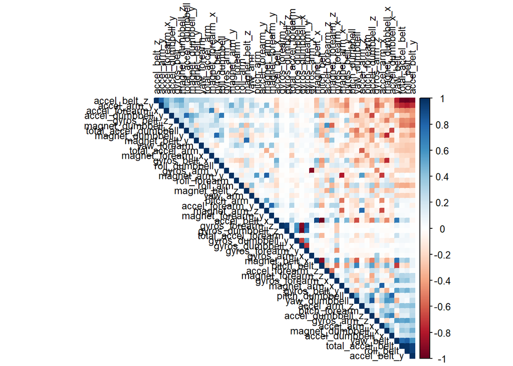

**Correlation Plot: The high color intensity points depict high correlation between variables.**

```r
cor_matrix <- cor(training[,-53])
corrplot(cor_matrix, order = "FPC", method = "color", type = "upper", tl.cex = 0.8, tl.col = rgb(0,0,0))
```

## Partitioning the data

Now that we have cleaned the data, let’s partition the data into training and validation sets. We’ll keep 70% of the data for training and will use the rest of it for validation test.

```r
inTrain <- createDataPartition(y=training$classe, p=0.7, list = FALSE)
trainData <- training[inTrain,]
validationData <- training[-inTrain,]
```

## Model Selection

For classification problems, algorithms such as Support Vector Machines(SVMs), Random Forests, Gradient Boosted Trees, Decision Trees, K-Nearest Neighbors, Linear Regression etc tends to work pretty well. So, we’ll try to model our data using these algorithms and compare their accuracies to select the best performing algorithm.

First, let’s try using **Support Vector Machines**:

```r
# Setting the training control parameter for 3-fold cross validation
ctrl <- trainControl(method = "cv", number = 3, verboseIter = FALSE)

# Training an SVM model
modelSVM <- train(classe ~ ., data=trainData, method="svmLinear", trControl = ctrl, tunelength = 5, verbose = FALSE)

# Predicting on validation data and checking for accuracy
predsSVM <- predict(modelSVM, validationData)
confusionMatrix(predsSVM, factor(validationData$classe))
```

```
Confusion Matrix and Statistics

          Reference
Prediction    A    B    C    D    E
         A 1552  139   99   71   74
         B   29  810   73   39  137
         C   49   84  789  106   71
         D   43   24   26  703   55
         E    1   82   39   45  745

Overall Statistics

               Accuracy : 0.7815
                 95% CI : (0.7707, 0.792)
    No Information Rate : 0.2845
    P-Value [Acc > NIR] : < 2.2e-16

                  Kappa : 0.722

 Mcnemar's Test P-Value : < 2.2e-16

Statistics by Class:

                     Class: A Class: B Class: C Class: D Class: E
Sensitivity            0.9271   0.7112   0.7690   0.7293   0.6885
Specificity            0.9090   0.9414   0.9362   0.9699   0.9652
Pos Pred Value         0.8021   0.7445   0.7179   0.8261   0.8169
Neg Pred Value         0.9691   0.9314   0.9505   0.9482   0.9322
Prevalence             0.2845   0.1935   0.1743   0.1638   0.1839
Detection Rate         0.2637   0.1376   0.1341   0.1195   0.1266
Detection Prevalence   0.3288   0.1849   0.1867   0.1446   0.1550
Balanced Accuracy      0.9181   0.8263   0.8526   0.8496   0.8269
```

We get 78.15% accuracy with Support Vector Machines algorithm. Now, let’s try using **Random Forest**:

```r
# Training a Random Forest model
modelRF <- train(classe ~ ., data = trainData, method = "rf", trControl = ctrl, tuneLength = 5)

# Predicting on validation data and checking for accuracy
predsRF <- predict(modelRF, validationData)
confusionMatrix(predsRF, factor(validationData$classe))
```

```
Confusion Matrix and Statistics

          Reference
Prediction    A    B    C    D    E
         A 1673    1    0    0    0
         B    1 1138   15    0    0
         C    0    0 1006    6    0
         D    0    0    5  957    5
         E    0    0    0    1 1077

Overall Statistics

               Accuracy : 0.9942
                 95% CI : (0.9919, 0.996)
    No Information Rate : 0.2845
    P-Value [Acc > NIR] : < 2.2e-16

                  Kappa : 0.9927

 Mcnemar's Test P-Value : NA

Statistics by Class:

                     Class: A Class: B Class: C Class: D Class: E
Sensitivity            0.9994   0.9991   0.9805   0.9927   0.9954
Specificity            0.9998   0.9966   0.9988   0.9980   0.9998
Pos Pred Value         0.9994   0.9861   0.9941   0.9897   0.9991
Neg Pred Value         0.9998   0.9998   0.9959   0.9986   0.9990
Prevalence             0.2845   0.1935   0.1743   0.1638   0.1839
Detection Rate         0.2843   0.1934   0.1709   0.1626   0.1830
Detection Prevalence   0.2845   0.1961   0.1720   0.1643   0.1832
Balanced Accuracy      0.9996   0.9979   0.9896   0.9954   0.9976
```

Random Forest gives us an accuracy of 99.42%. Next, let’s try using **Gradient Boosted Trees**:

```r
# Training a Gradient Boosted Trees model
modelGBT <- train(classe ~ ., data = trainData, method = "gbm", trControl = ctrl, tuneLength = 5, verbose = FALSE)

# Predicting on validation data and checking for accuracy
predsGBT <- predict(modelGBT, validationData)
confusionMatrix(predsGBT, factor(validationData$classe))
```

```
Confusion Matrix and Statistics

          Reference
Prediction    A    B    C    D    E
         A 1667    5    0    0    0
         B    3 1128   20    1    3
         C    3    6  998   10    3
         D    1    0    8  947    6
         E    0    0    0    6 1070

Overall Statistics

               Accuracy : 0.9873
                 95% CI : (0.9841, 0.99)
    No Information Rate : 0.2845
    P-Value [Acc > NIR] : < 2.2e-16

                  Kappa : 0.9839

 Mcnemar's Test P-Value : NA

Statistics by Class:

                     Class: A Class: B Class: C Class: D Class: E
Sensitivity            0.9958   0.9903   0.9727   0.9824   0.9889
Specificity            0.9988   0.9943   0.9955   0.9970   0.9988
Pos Pred Value         0.9970   0.9766   0.9784   0.9844   0.9944
Neg Pred Value         0.9983   0.9977   0.9942   0.9965   0.9975
Prevalence             0.2845   0.1935   0.1743   0.1638   0.1839
Detection Rate         0.2833   0.1917   0.1696   0.1609   0.1818
Detection Prevalence   0.2841   0.1963   0.1733   0.1635   0.1828
Balanced Accuracy      0.9973   0.9923   0.9841   0.9897   0.9938
```

Gradient Boosted Trees gives an accuracy of 98.73.%, and looking at the accuracies, it seems that these 3 models are sufficient for our purpose and comparing the accuracies, and the Random Forest algorithm models our data best.

## Predicting on Test dataset

Since we’ve selected our model, we’ll now predict on test dataset:

```r
predsTest <- predict(modelRF, testing)
predsTest
```

```
 [1] B A B A A E D B A A B C B A E E A B B B
Levels: A B C D E
```

[^1]: Velloso, E.; Bulling, A.; Gellersen, H.; Ugulino, W.; Fuks, H. Qualitative Activity Recognition of Weight Lifting Exercises. Proceedings of 4th International Conference in Cooperation with SIGCHI (Augmented Human ’13) . Stuttgart, Germany: ACM SIGCHI, 2013; Read more at: http://web.archive.org/web/20161217164008/http://groupware.les.inf.puc-rio.br/work.jsf?p1=11201